# Titanic Ángela Durán Pinto and Francisco José Landa Ortega

# Final Titanic

In this project, we will further analyze the Titanic dataset provided. Having done an exploratiry analysis and highlighting the most important variables, we will try to make predictions but first lets load the libraries and of course, the dataset we will use.

### Libraries and Preprocessing

```r
library(rpart)
library(rpart.plot)
library(randomForest)
library(ggplot2)
library(caret)
setwd("/Users/curro/Desktop/TitanicFinal")
```

We read the dataset and change the name from titanic.train to df (dataframe) for an easier work for us.

```r
load("titanic_train.Rdata")
df <- titanic.train
head(df)
```

|  | Survived | Pclass | Sex | Age | SibSp | Parch | Ticket | Fare | Cabin | Embarked |
| --- | --- | --- | --- | --- | --- | --- | --- | --- | --- | --- |
| 2 | 1 | 1 | female | 38 | 1 | 0 | PC 17599 | 71.2833 | C85 | C |
| 5 | 0 | 3 | male | 35 | 0 | 0 | 373450 | 8.0500 |  | S |
| 7 | 0 | 1 | male | 54 | 0 | 0 | 17463 | 51.8625 | E46 | S |
| 10 | 1 | 2 | female | 14 | 1 | 0 | 237736 | 30.0708 |  | C |
| 11 | 1 | 3 | female | 4 | 1 | 1 | PP 9549 | 16.7000 | G6 | S |
| 14 | 0 | 3 | male | 39 | 1 | 5 | 347082 | 31.2750 |  | S |

We drop the columns which are useless in our opinion for this analysis, Cabin and Ticket.

```r
drop <- names(df) %in% c("Cabin", "Ticket")
df <- df[,!drop]
head(df)
```

|  | Survived | Pclass | Sex | Age | SibSp | Parch | Fare | Embarked |
| --- | --- | --- | --- | --- | --- | --- | --- | --- |
| 2 | 1 | 1 | female | 38 | 1 | 0 | 71.2833 | C |
| 5 | 0 | 3 | male | 35 | 0 | 0 | 8.0500 | S |
| 7 | 0 | 1 | male | 54 | 0 | 0 | 51.8625 | S |
| 10 | 1 | 2 | female | 14 | 1 | 0 | 30.0708 | C |
| 11 | 1 | 3 | female | 4 | 1 | 1 | 16.7000 | S |
| 14 | 0 | 3 | male | 39 | 1 | 5 | 31.2750 | S |

```r
df$Survived = factor(df$Survived,levels = c(0,1),labels=c("Died","Survived"))
df
```

|  | Survived | Pclass | Sex | Age | SibSp | Parch | Fare | Embarked |
| --- | --- | --- | --- | --- | --- | --- | --- | --- |
| 2 | Survived | 1 | female | 38.00 | 1 | 0 | 71.2833 | C |
| 5 | Died | 3 | male | 35.00 | 0 | 0 | 8.0500 | S |
| 7 | Died | 1 | male | 54.00 | 0 | 0 | 51.8625 | S |
| 10 | Survived | 2 | female | 14.00 | 1 | 0 | 30.0708 | C |
| 11 | Survived | 3 | female | 4.00 | 1 | 1 | 16.7000 | S |
| 14 | Died | 3 | male | 39.00 | 1 | 5 | 31.2750 | S |
| 15 | Died | 3 | female | 14.00 | 0 | 0 | 7.8542 | S |
| 16 | Survived | 2 | female | 55.00 | 0 | 0 | 16.0000 | S |
| 17 | Died | 3 | male | 2.00 | 4 | 1 | 29.1250 | Q |
| 18 | Survived | 2 | male | 28.00 | 0 | 0 | 13.0000 | S |

[output cut: 658 more lines]

### Decision Trees

We now use a decision tree, with default hyperparameters to have a preliminary insight of the prediction, we first split the dataset into train and test sets. In this case, the relation will be 80% for train and 20% for test.

```r
set.seed(123)
idx = sample(1:nrow(df), floor(nrow(df)*0.8))
df_train = df[idx,]
df_test = df[-idx,]
```

We can see that the relation between Survived and not Survived remains like when we made the analysis on the first delivery of this project. Around 60% not survived and 40% survived

```r
prop.table(table(df_train$Survived))
```

```
     Died  Survived
0.6067416 0.3932584
```

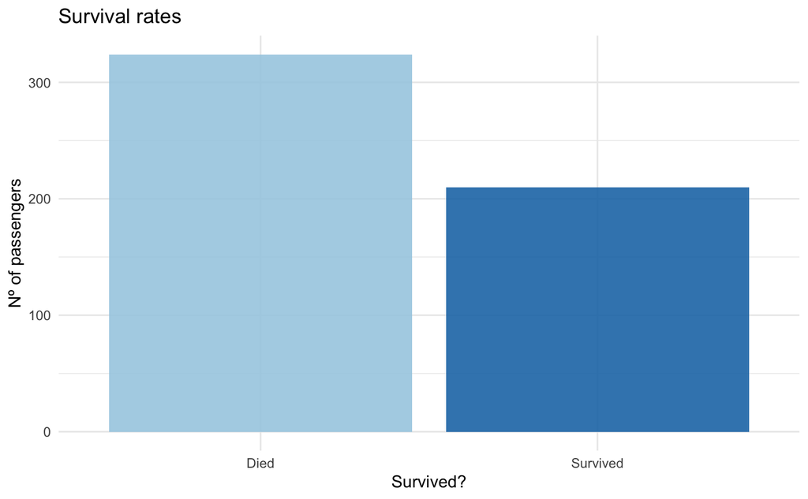

```r
ggplot(df_train)+
  geom_bar(aes(x = Survived, fill = Survived), alpha=0.9)+  labs(title="Survival rates",
       x="Survived?",
       y="Nº of passengers") +
  scale_fill_brewer(palette = "Paired")+
  theme_minimal()+
  scale_x_discrete(labels=c("Died", "Survived"))+ theme(legend.position='none')
```

We prepare and plot the decision tree. We are going to leave the default settings.

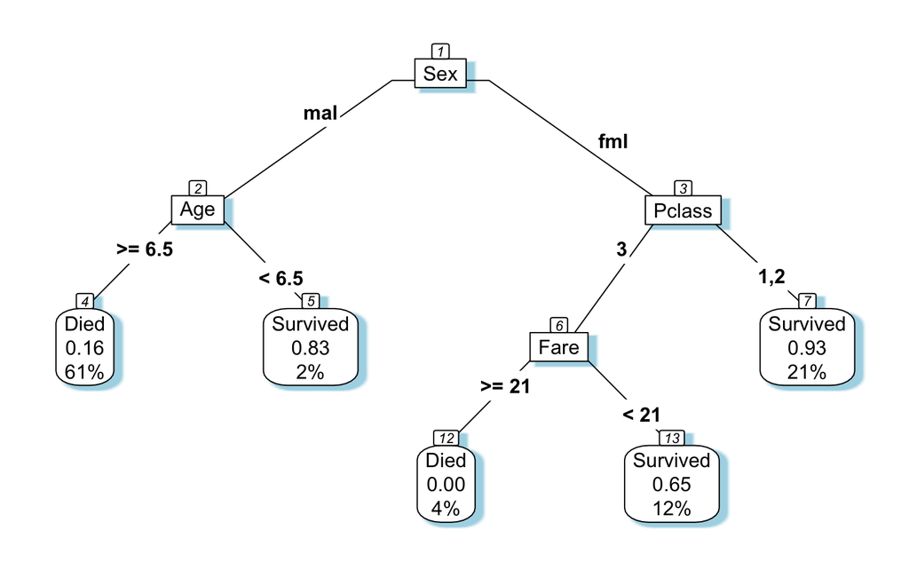

```r
tree = rpart(formula=Survived~., data = df_train , method = "class")
prp(tree,
    type=5,
    extra=106,
    nn = TRUE,
    shadow.col = "lightblue",
    digits = 2,
    roundint = TRUE)
```

We can look at the variables which the classifier has given more importance with the following line.

```r
tree$variable.importance
```

```
      Sex      Fare    Pclass       Age     Parch     SibSp  Embarked
78.816668 27.797710 17.622807 16.855279 14.793065 10.508174  3.438596
```

Sex, as we expected, SEX is the most relevant. It determines your survival chances a lot. Being a man over 7 years old gives you a 16% chance of survival while, if being a woman your chances of survival are between a 93% and a 65% (0 if you are in 3rd class and overpaid for the ticket). The results of our initial analysis are now supported by this decision tree, lets look at the predictions.

```r
pred = predict(tree, df_test, type = "class")
conf_matrix = table(df_test$Survived, pred, dnn =c("Real value", "Prediction"))
conf_matrix
```

```
          Prediction
Real value Died Survived
  Died       78       10
  Survived   15       31
```

And now at the performance of the tree.

```r
accuracy = sum(diag(conf_matrix))/sum(conf_matrix)
precision = conf_matrix[1,1]/sum(conf_matrix[,1])
specificity = conf_matrix[2,2]/sum(conf_matrix[,2])
performance = data.frame(accuracy,precision,specificity)
performance
```

| accuracy | precision | specificity |
| --- | --- | --- |
| 0.8134328 | 0.8387097 | 0.7560976 |

We have got a not that bad accuracy, a better precision but not the best possible specificity, having classified someone who survived as someone who didn’t. This model shows a performance of around an 81%.

Now lets look for the best hyperparameters for a decision tree using in addition K-folds. We will use the code provided in class, changing some parameters for them to fit in our study case. We will set the number of folds to 10 because a high number of these can result in both overfitting and an unnecessary long computing time. The code for the Kfolds has been obtained from the practice lessons and been a little bit modified by us.

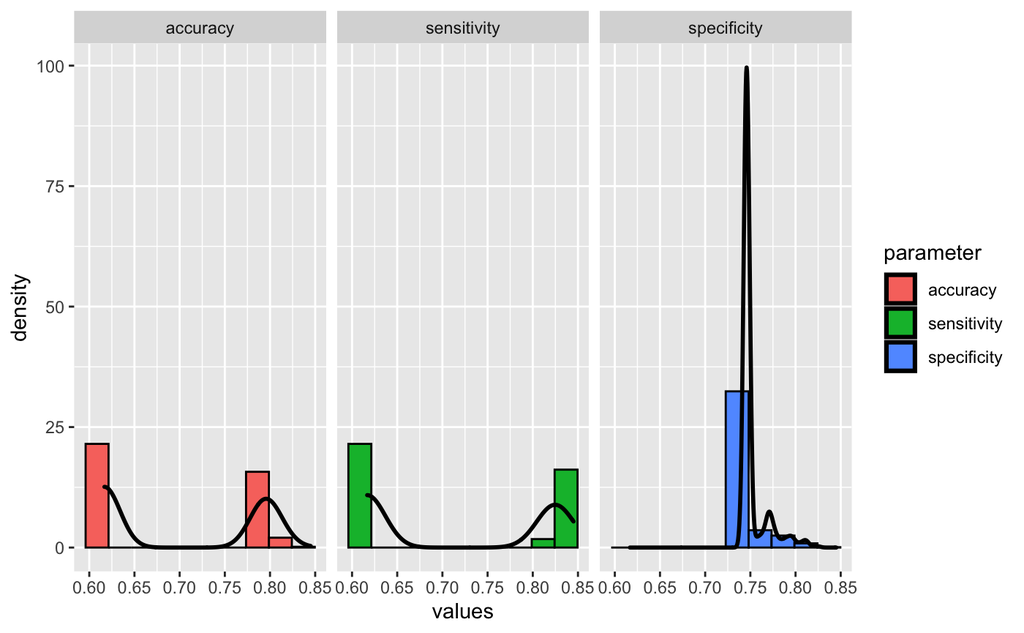

```r
set.seed(123)
d_minsplit=seq(from=2,to=40,by=2)
d_maxdepth=seq(from=1,to=10,by=1)
d_cp=seq(from=0,to=1,by=0.1)
parametros=expand.grid(minsplit=d_minsplit,maxdepth=d_maxdepth,cp=d_cp)

nfolds = 10
folds = createFolds(df$Survived, k = nfolds)

cv_hyper = apply(parametros,1,function(y){
  cv = lapply(folds, function(x) {
    training_set = df[-x,]
    test_set = df[x,]
    mytree=rpart(formula=Survived ~., data=training_set, method="class",
                 control = rpart.control(minsplit=y[1],maxdepth=y[2],cp=y[3]))
    pred = predict(mytree,test_set,type="class")

    conf_matrix = table(test_set$Survived,pred,dnn=c("Real value","Prediction"))

    accuracy = sum(diag(conf_matrix))/sum(conf_matrix)
    sensitivity = conf_matrix[1,1]/sum(conf_matrix[,1])
    specificity = conf_matrix[2,2]/sum(conf_matrix[,2])
    return(c(accuracy,sensitivity,specificity))
  })

  modqualres = data.frame(t(matrix(unlist(cv),nrow = 3)))
  names(modqualres)=c("accuracy","sensitivity","specificity")

  return(c(mean(modqualres$accuracy),mean(modqualres$sensitivity),mean(modqualres$specificity)))
})

performance=data.frame(values=c(cv_hyper[1,],
                                cv_hyper[2,],
                                cv_hyper[3,]),
                                parameter=as.factor(c(rep("accuracy",dim(cv_hyper)[2]),
                                                      rep("sensitivity",dim(cv_hyper)[2]),
                                                      rep("specificity",dim(cv_hyper)[2]))))



ggplot(data=performance)+aes(x=values,fill=parameter)+
  geom_histogram(bins=10, colour="black",aes(y=..density..))+
  geom_density( colour="black",alpha=0,size=1)+facet_grid(.~parameter)
```

And finally, our model will have, not the parameters that obtain the highest accuracy but those who obtain the best ballanced performance.

```r
parametros[which.max(apply(cv_hyper,MARGIN = 2,FUN=mean)),]
```

|  | minsplit | maxdepth | cp |
| --- | --- | --- | --- |
| 44 | 8 | 3 | 0 |

```r
cv_hyper[,which.max(apply(cv_hyper,MARGIN = 2,FUN=mean))]
```

```
[1] 0.8293446 0.8364229 0.8245720
```

Having obtained the parameters we create the tree.

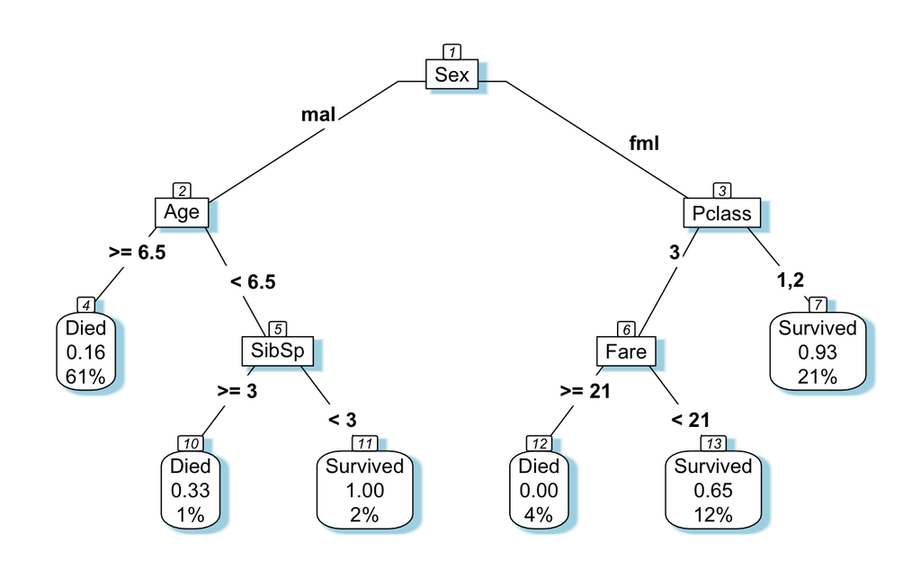

```r
set.seed(123)
tree = rpart(formula=Survived~., data = df_train , method = "class",
    control = rpart.control(minsplit=8,
                            maxdepth=3,
                            cp=0))
prp(tree,
    type=5,
    extra=106,
    nn = TRUE,
    shadow.col = "lightblue",
    digits = 2,
    roundint = TRUE)
```

And we check the results with the test set.

```r
tree$variable.importance
```

```
      Sex      Fare    Pclass       Age     Parch     SibSp  Embarked
78.816668 27.797710 17.622807 16.855279 14.793065 12.508174  4.105263
```

```r
pred = predict(tree, df_test, type = "class")
conf_matrix = table(df_test$Survived, pred, dnn =c("Real value", "Prediction"))
conf_matrix
```

```
          Prediction
Real value Died Survived
  Died       81        7
  Survived   15       31
```

And now at the accuracy

```r
accuracy = sum(diag(conf_matrix))/sum(conf_matrix)
precision = conf_matrix[1,1]/sum(conf_matrix[,1])
specificity = conf_matrix[2,2]/sum(conf_matrix[,2])
performance = data.frame(accuracy,precision,specificity)
performance
```

| accuracy | precision | specificity |
| --- | --- | --- |
| 0.8358209 | 0.84375 | 0.8157895 |

This tree has now got a quite good performance, lets now try Random Forest.

### Random Forest

Lets try a default Random Forest

```r
set.seed(123)
rf = randomForest(formula = Survived~.,data = df_train)
pred=predict(rf, df_test)
conf_matrix = table(df_test$Survived,pred,dnn=c("Real value","Prediction"))
conf_matrix
```

```
          Prediction
Real value Died Survived
  Died       80        8
  Survived   14       32
```

```r
accuracy = sum(diag(conf_matrix))/sum(conf_matrix)
precision = conf_matrix[1,1]/sum(conf_matrix[,1])
specificity = conf_matrix[2,2]/sum(conf_matrix[,2])
performance = data.frame(accuracy,precision,specificity)
performance
```

| accuracy | precision | specificity |
| --- | --- | --- |
| 0.8358209 | 0.8510638 | 0.8 |

Notice that it has a very good performance if compared to the decision tree in default parameters as well. Now we will use Kfolds to get the best possible parameters. We will also use some of the code provided by the teacher.

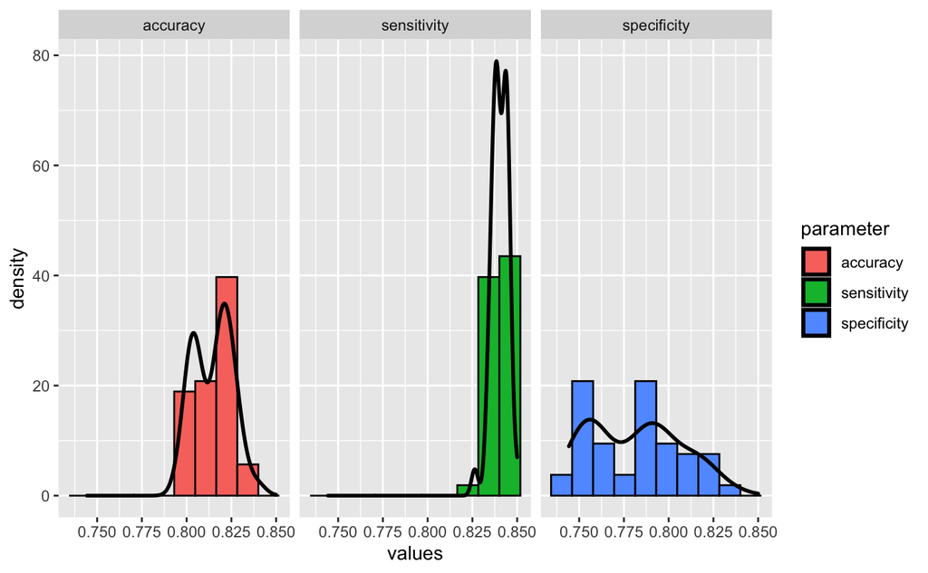

```r
set.seed(123)
d_mtry = seq(from=2,to=6,by=1)
d_ntree = seq(from=100,to=500,by=50)
parameters = expand.grid(mtry=d_mtry, ntree=d_ntree)
y = parameters[1,]

nfolds = createFolds(df$Survived, k = 10)

cv_hyper = apply(parameters,1,function(y){
  cv = lapply(nfolds, function(x) {
    training_set = df[-x,]
    test_set = df[x,]
    mytree = randomForest(formula = Survived~.,
                              data = training_set,
                              mtry = y[1],
                              ntree = y[2])
    pred=predict(mytree, test_set)

    conf_matrix = table(test_set$Survived,pred,dnn=c("Real value","Prediction"))

    accuracy = sum(diag(conf_matrix))/sum(conf_matrix)
    sensitivity = conf_matrix[1,1]/sum(conf_matrix[,1])
    specificity = conf_matrix[2,2]/sum(conf_matrix[,2])
    return(c(accuracy,sensitivity,specificity))
  })

  modqualres = data.frame(t(matrix(unlist(cv),nrow = 3)))
  names(modqualres)=c("accuracy","sensitivity","specificity")

  return(c(mean(modqualres$accuracy),mean(modqualres$sensitivity),mean(modqualres$specificity)))
})

performance=data.frame(values=c(cv_hyper[1,],
                                cv_hyper[2,],
                                cv_hyper[3,]),
                                parameter=as.factor(c(rep("accuracy",dim(cv_hyper)[2]),
                                                      rep("sensitivity",dim(cv_hyper)[2]),
                                                      rep("specificity",dim(cv_hyper)[2]))))


ggplot(data=performance)+aes(x=values,fill=parameter)+
  geom_histogram(bins=10, colour="black",aes(y=..density..))+
  geom_density( colour="black",alpha=0,size=1)+facet_grid(.~parameter)
```

And selecting the best combination we obtain…

```r
parameters[which.max(apply(cv_hyper,MARGIN = 2,FUN=mean)),]
```

|  | mtry | ntree |
| --- | --- | --- |
| 11 | 2 | 200 |

```r
cv_hyper[,which.max(apply(cv_hyper,MARGIN = 2,FUN=mean))]
```

```
[1] 0.8398163 0.8451694 0.8347448
```

```r
best=parameters[which.max(apply(cv_hyper,MARGIN = 2,FUN=mean)),]
```

We can see that Random Forest is better than the decision tree for this study. Lets build our final model using these new parameters.

### Final Model

```r
set.seed(123)
bestclassifier = randomForest(formula = Survived~.,data = df_train,mtry=best[1,1], ntree=best[1,2])

my_model = function(test_set){
  # We have to make the same preprocessing to my test set storaged in variable test_set
  drop <- names(test_set) %in% c("Cabin", "Ticket")
  test_set <- test_set[,!drop]
  # Use the best classifier to forecast survival
  pred = predict(bestclassifier,test_set,type="class")
  # Compute the confusion matrix
  conf_matrix = table(test_set$Survived,pred,dnn=c("Actual value","Classifier prediction"))
  # Compute error estimates
  accuracy = sum(diag(conf_matrix))/sum(conf_matrix)
  precision = conf_matrix[1,1]/sum(conf_matrix[,1])
  specificity = conf_matrix[2,2]/sum(conf_matrix[,2])
  return(list(prediction=pred,
              conf_matrix=conf_matrix,
              accuracy=accuracy,
              precision=precision,
              specificity=specificity))
}

save(bestclassifier,my_model,file="my_model.RData")

my_model(df_test)
```

[output not shown]

### Conclusion

After the Exploratory Analysis and some Machine Learning algorithms, our beliefs came true. What influences more your chances of survival is the Sex, being man lowers a lot your survival chances.